# Homework Task 2 – Basics in R

Due: Thursday, May 2 by 08:59 CET

# Instructions

- Work together within your group.
- Make sure you have R and RStudio installed. If you are an advanced user and aren’t using RStudio, make sure you have `rmarkdown` in order to ‘knit’ the HTML output.
- Download [this zip file](https://michael-franke.github.io/XPLab_2019/homework/XPLab_2019_HW2.zip). It contains an .Rmd file that you will edit and submit.
- Open the .Rmd file in RStudio.
- Fill in your names in the ‘author’ heading.
- Fill in the required code and answers.
- ‘Knit’ the document (`ctrl/cmd` + `shift` + `K` in RStudio) to produce a HTML file.
- Push both the files to your group’s Git repository before the deadline.
- Using Github Pages, make a page that displays the knitted html file.

# Suggested readings

- [R4DS](http://r4ds.had.co.nz/) (R for Data Science).

# Required R packages

- `tidyverse` (or `ggplot2`, `dplyr`, `purrr`, `tibble`)

```r
set.seed(123) # this ensures that any psuedo-random computations are always the same
```

# 1. Installing and running R

## a.

Your first task is simply to show that you have been able to install and run R and R Markdown. You don’t have to change this code, just uncomment it. Then the correct output will automatically appear when you ‘knit’ the document.

```r
# UNCOMMENT THE CODE

R.version
```

```
##                _
## platform       x86_64-w64-mingw32
## arch           x86_64
## os             mingw32
## system         x86_64, mingw32
## status
## major          3
## minor          5.1
## year           2018
## month          07
## day            02
## svn rev        74947
## language       R
## version.string R version 3.5.1 (2018-07-02)
## nickname       Feather Spray
```

[session information not shown]

**Which version of R are you running? On which platform are you running it?**

## b.

Install the package `tidyverse`. Don’t install it in the code below. Instead, install it through the console. Then write code below to load the package and show the `sessionInfo` again.

```r
# YOUR CODE HERE
library(tidyverse)
```

[session information not shown]

**Which version of `tidyverse` do you have installed?**

# 2. Tibbles (tidy tables)

The ToothGrowth data set comes with base R. You can read about this data set by running `?ToothGrowth` in the console. It is a data frame. In this course, we prefer to use tibbles (tidy tables) instead of data frames.

## a.

Convert the `ToothGrowth` data frame into a tibble using `as_tibble()`. Put this in a new variable called `iris_tibble`. Then print the tibble using the `print()` function.

```r
# YOUR CODE HERE
iris_tibble <- as_tibble(ToothGrowth)
print(iris_tibble)
```

```
## # A tibble: 60 x 3
##      len supp   dose
##    <dbl> <fct> <dbl>
##  1   4.2 VC      0.5
##  2  11.5 VC      0.5
##  3   7.3 VC      0.5
##  4   5.8 VC      0.5
##  5   6.4 VC      0.5
##  6  10   VC      0.5
##  7  11.2 VC      0.5
##  8  11.2 VC      0.5
##  9   5.2 VC      0.5
## 10   7   VC      0.5
## # ... with 50 more rows
```

**Which data type is the variable “supp”?**

## b.

Starting from the complete `ToothGrowth` data set, filter only the guinea pigs that were give orange juice.

```r
# YOUR CODE HERE
filter(iris_tibble, supp =="OJ")
```

```
## # A tibble: 30 x 3
##      len supp   dose
##    <dbl> <fct> <dbl>
##  1  15.2 OJ      0.5
##  2  21.5 OJ      0.5
##  3  17.6 OJ      0.5
##  4   9.7 OJ      0.5
##  5  14.5 OJ      0.5
##  6  10   OJ      0.5
##  7   8.2 OJ      0.5
##  8   9.4 OJ      0.5
##  9  16.5 OJ      0.5
## 10   9.7 OJ      0.5
## # ... with 20 more rows
```

**How many datapoints (i.e. guinea pigs) are left?**

## c.

Starting from the complete `ToothGrowth` data set, filter only the guinea pigs that received ascorbic acid and had a dosage of 1.0mg or greater.

```r
# YOUR CODE HERE

filter(iris_tibble, supp == "VC"& dose >= 1.0)
```

```
## # A tibble: 20 x 3
##      len supp   dose
##    <dbl> <fct> <dbl>
##  1  16.5 VC        1
##  2  16.5 VC        1
##  3  15.2 VC        1
##  4  17.3 VC        1
##  5  22.5 VC        1
##  6  17.3 VC        1
##  7  13.6 VC        1
##  8  14.5 VC        1
##  9  18.8 VC        1
## 10  15.5 VC        1
## 11  23.6 VC        2
## 12  18.5 VC        2
## 13  33.9 VC        2
## 14  25.5 VC        2
## 15  26.4 VC        2
## 16  32.5 VC        2
## 17  26.7 VC        2
## 18  21.5 VC        2
## 19  23.3 VC        2
## 20  29.5 VC        2
```

## d.

Find out the mean length for the two supplement types. Do this with by piping `tooth_growth_tibble` to `group_by()` and then to `summarise()`. For instructions read the help page for `summarise()`.

```r
# YOUR CODE HERE
iris_tibble %>% group_by(supp)%>% summarise(mean(len))
```

```
## # A tibble: 2 x 2
##   supp  `mean(len)`
##   <fct>       <dbl>
## 1 OJ           20.7
## 2 VC           17.0
```

**What is the mean tooth length for guinea pigs that received Orange Juice?**

# 3. Plotting data

## a.

Using the `ToothGrowth` data set, create a plot of dose (x axis) against length (y axis) using `ggplot()`. Show the two supplement types in different colours.

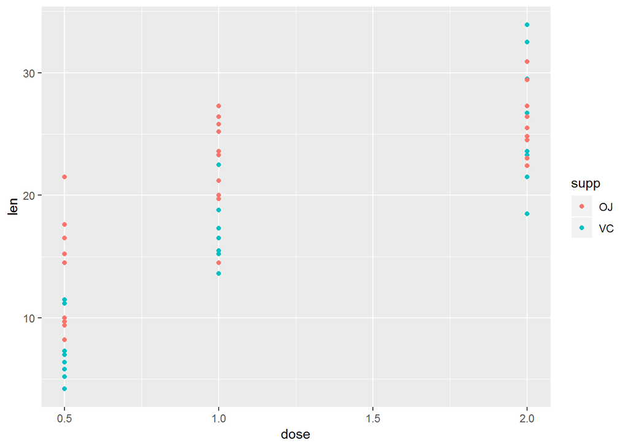

```r
# YOUR CODE HERE
ggplot(iris_tibble) + geom_point(mapping=aes(x=dose,y=len, color=supp))
```

**After visually inspecting the graph, does there seem to be any difference between the types of supplement?**

End of homework sheet